# IMF Online Course: Macroeconomic forecasting

## Module 3A: Statistical Properties of Time Series Data

### Estimation with Stationary Time Series and Model Selection

**Author**: Miha Tro?t  
**Date**: 05-07-2021

```r
# useful libraries
library(plyr)
library(dplyr)
library(forecast)
library(stringr)
library(lubridate)
library(tidyr)
library(broom)
```

```r
setwd("C:\\Users\\pc\\Desktop\\Macroeconometric-Forecasting-EDX\\Módulo 3a - Statistical properties of time series\\Arquivos csv's")

m3_data <- read.csv("module3_data_Identifying_ARMA.csv")

# my_df <-
#   read.csv(str_c(my_wd, "module3_data_PE_Ratios.csv"),
#            sep = ",",
#            stringsAsFactors = FALSE)
```

### Working with Simulated Data

#### QUESTION 3.25

Note that the series y was simulated following the model (where the error term is a white noise):

y<sub>t</sub> = 1.2 * y<sub>t-1</sub> - 0.5 * y<sub>t-2</sub> + e<sub>t</sub>

```r
y <- vector()
y <- rep(0, 2)

n <- 500
e <- rnorm(n)

for(i in 3:n){

  y[i] <- 1.2 * y[i - 1] - 0.5 * y[i - 2] + m3_data$et[i]

}
```

Plot the series.

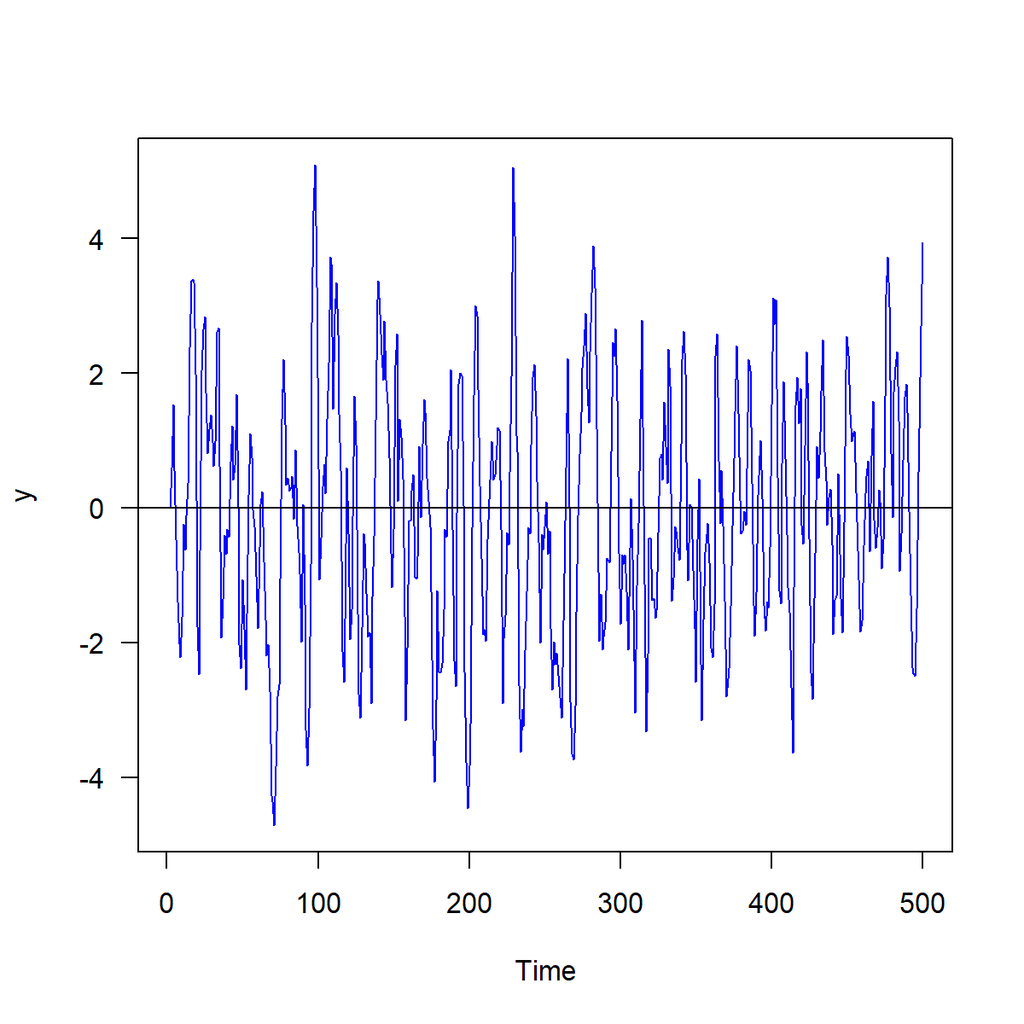

```r
plot.ts(y, col = "blue", las = 1)
abline(h = 0)
```

Based on the equation above, series y is simulated as what of process?

The series y is simulated as AR(2) process.

### Estimating Different Models

#### QUESTION 3.26

Enter the SBC (Schwarz criterion) for each model (to three decimal places, without any rounding):

```r
model_1 <-
  Arima(y, order = c(1, 0, 0), method = "ML")

model_2 <-
  Arima(y, order = c(2, 0, 0), method = "ML")
```

**AR(1)**:

The BIC for model 1 (calculated in R) is 1566.4288065.

**AR(2)**:

The BIC for model 2 (calculated in R) is 1422.9793153.

#### QUESTION 3.27

Enter the p-value (to three decimal places, without any rounding) for the lag 12 Q-test on the regression residuals for each model:

```r
box_m1 <-
  Box.test(residuals(model_1), lag = 12, fitdf = 0)

box_m2 <-
  Box.test(residuals(model_2), lag = 12, fitdf = 0)
```

**AR(1)**:

The p-value for model 1 (calculated in R) is 0.

#### QUESTION 3.28

If the regression residuals are white noise and using a 10 percent level of significance, to conclude that there is no auto-correlation at a certain lag length the p-value should be:

Greater than 0.1.

#### QUESTION 3.29

Do the regression diagnostics favor the true (i.e., AR(2)) model for y? In other words, does the true model clearly perform better than the other?

Yes.

### Automatic ARIMA Forecasting

With series y run `Automatic ARIMA Forecasting`.

Specification:

- Transformation: None
- Max differencing: 0
- Max AR and Max MA: 6
- Max SAR and SMA: 0

Options:

- Model Selection?Akaike Information Criterion
- Eviews: Check the boxes for ARMA Criteria Table, ARMA Criteria Graph, Equation Output Table.

#### QUESTION 3.30

Which model was chosen as the best?

```r
auto.arima(y, # my time series
           stationary = TRUE, # restrict search to stationary models
           d = 0, # differences
           D = 0, # seasonal differences
           max.p = 6, # max AR terms
           max.q = 6, # max MA terms
           max.P = 0, # max SAR terms
           max.Q = 0, # max SMA terms
           trace = TRUE, # show models as estimated
           stepwise = FALSE)
```

```
 Fitting models using approximations to speed things up...

 ARIMA(0,0,0) with zero mean     : 2015.334
 ARIMA(0,0,0) with non-zero mean : 2015.996
 ARIMA(0,0,1) with zero mean     : 1603.196
 ARIMA(0,0,1) with non-zero mean : 1604.316
 ARIMA(0,0,2) with zero mean     : 1453.528
 ARIMA(0,0,2) with non-zero mean : 1455.073
 ARIMA(0,0,3) with zero mean     : 1407.963
 ARIMA(0,0,3) with non-zero mean : 1409.699
 ARIMA(0,0,4) with zero mean     : 1405.226
 ARIMA(0,0,4) with non-zero mean : 1407.025
 ARIMA(0,0,5) with zero mean     : 1407.248
 ARIMA(0,0,5) with non-zero mean : 1409.061
 ARIMA(1,0,0) with zero mean     : 1551.946
 ARIMA(1,0,0) with non-zero mean : 1553.891
 ARIMA(1,0,1) with zero mean     : 1427.225
 ARIMA(1,0,1) with non-zero mean : 1429.095
 ARIMA(1,0,2) with zero mean     : 1410.446
 ARIMA(1,0,2) with non-zero mean : 1412.259
 ARIMA(1,0,3) with zero mean     : 1406.644
 ARIMA(1,0,3) with non-zero mean : 1408.419
 ARIMA(1,0,4) with zero mean     : 1408.253
 ARIMA(1,0,4) with non-zero mean : 1410.017
 ARIMA(2,0,0) with zero mean     : 1405.067
 ARIMA(2,0,0) with non-zero mean : 1406.662
 ARIMA(2,0,1) with zero mean     : 1403.336
 ARIMA(2,0,1) with non-zero mean : 1405.017
 ARIMA(2,0,2) with zero mean     : 1405.368
 ARIMA(2,0,2) with non-zero mean : 1407.05
 ARIMA(2,0,3) with zero mean     : 1407.054
 ARIMA(2,0,3) with non-zero mean : 1408.678
 ARIMA(3,0,0) with zero mean     : 1404.176
 ARIMA(3,0,0) with non-zero mean : 1405.829
 ARIMA(3,0,1) with zero mean     : 1406.173
 ARIMA(3,0,1) with non-zero mean : 1407.836
 ARIMA(3,0,2) with zero mean     : 1407.905
 ARIMA(3,0,2) with non-zero mean : 1409.508
 ARIMA(4,0,0) with zero mean     : 1406.202
 ARIMA(4,0,0) with non-zero mean : 1407.785
 ARIMA(4,0,1) with zero mean     : 1407.84
 ARIMA(4,0,1) with non-zero mean : 1409.455
 ARIMA(5,0,0) with zero mean     : 1407.814
 ARIMA(5,0,0) with non-zero mean : 1409.435

 Now re-fitting the best model(s) without approximations...




 Best model: ARIMA(2,0,1) with zero mean
```

```
Series: y
ARIMA(2,0,1) with zero mean

Coefficients:
         ar1      ar2     ma1
      1.0521  -0.4118  0.1698
s.e.  0.0784   0.0681  0.0851

sigma^2 estimated as 0.9557:  log likelihood=-697.41
AIC=1402.81   AICc=1402.89   BIC=1419.67
```

**None of the following**: AR(1), AR(2), ARMA(1, 1).

#### QUESTION 3.31

Without re-running the model, would the use of a different criterion have resulted in a different model being chosen as the best?

```r
auto.arima(y, # my time series
           stationary = TRUE, # restrict search to stationary models
           d = 0, # differences
           D = 0, # seasonal differences
           max.p = 6, # max AR terms
           max.q = 6, # max MA terms
           max.P = 0, # max SAR terms
           max.Q = 0, # max SMA terms
           trace = TRUE, # show models as estimated
           stepwise = FALSE,
           ic = "bic")
```

```
 Fitting models using approximations to speed things up...

 ARIMA(0,0,0) with zero mean     : 2019.541
 ARIMA(0,0,0) with non-zero mean : 2024.401
 ARIMA(0,0,1) with zero mean     : 1611.601
 ARIMA(0,0,1) with non-zero mean : 1616.912
 ARIMA(0,0,2) with zero mean     : 1466.124
 ARIMA(0,0,2) with non-zero mean : 1471.851
 ARIMA(0,0,3) with zero mean     : 1424.741
 ARIMA(0,0,3) with non-zero mean : 1430.651
 ARIMA(0,0,4) with zero mean     : 1426.178
 ARIMA(0,0,4) with non-zero mean : 1432.143
 ARIMA(0,0,5) with zero mean     : 1432.365
 ARIMA(0,0,5) with non-zero mean : 1438.336
 ARIMA(1,0,0) with zero mean     : 1560.351
 ARIMA(1,0,0) with non-zero mean : 1566.486
 ARIMA(1,0,1) with zero mean     : 1439.82
 ARIMA(1,0,1) with non-zero mean : 1445.872
 ARIMA(1,0,2) with zero mean     : 1427.223
 ARIMA(1,0,2) with non-zero mean : 1433.211
 ARIMA(1,0,3) with zero mean     : 1427.596
 ARIMA(1,0,3) with non-zero mean : 1433.536
 ARIMA(1,0,4) with zero mean     : 1433.37
 ARIMA(1,0,4) with non-zero mean : 1439.292
 ARIMA(2,0,0) with zero mean     : 1417.662
 ARIMA(2,0,0) with non-zero mean : 1423.44
 ARIMA(2,0,1) with zero mean     : 1420.113
 ARIMA(2,0,1) with non-zero mean : 1425.969
 ARIMA(2,0,2) with zero mean     : 1426.32
 ARIMA(2,0,2) with non-zero mean : 1432.167
 ARIMA(2,0,3) with zero mean     : 1432.171
 ARIMA(2,0,3) with non-zero mean : 1437.953
 ARIMA(3,0,0) with zero mean     : 1420.953
 ARIMA(3,0,0) with non-zero mean : 1426.781
 ARIMA(3,0,1) with zero mean     : 1427.124
 ARIMA(3,0,1) with non-zero mean : 1432.954
 ARIMA(3,0,2) with zero mean     : 1433.023
 ARIMA(3,0,2) with non-zero mean : 1438.783
 ARIMA(4,0,0) with zero mean     : 1427.153
 ARIMA(4,0,0) with non-zero mean : 1432.902
 ARIMA(4,0,1) with zero mean     : 1432.957
 ARIMA(4,0,1) with non-zero mean : 1438.729
 ARIMA(5,0,0) with zero mean     : 1432.931
 ARIMA(5,0,0) with non-zero mean : 1438.71

 Now re-fitting the best model(s) without approximations...




 Best model: ARIMA(2,0,0) with zero mean
```

```
Series: y
ARIMA(2,0,0) with zero mean

Coefficients:
         ar1      ar2
      1.1770  -0.5094
s.e.  0.0385   0.0386

sigma^2 estimated as 0.961:  log likelihood=-699.28
AIC=1404.56   AICc=1404.6   BIC=1417.2
```

The true model would have been selected.